# 1900159_Robin Viltoriano_assign1a

## Assignment 1a: Machine Learning Methods

### Robin Viltoriano / 1900159

#### How can we use data analytics to predict energy usage for this house?

[figure not shown]

#### Follow detail instructions in the assignment specification and use these heading for implementation and discussion

```python
import warnings

# Ignore all warnings
warnings.filterwarnings("ignore",category=FutureWarning)

import pandas as pd
import numpy as np
from sklearn.decomposition import PCA
from sklearn.ensemble import RandomForestRegressor

import matplotlib.pyplot as plt
```

### 1. Read the dataset

```python
df = pd.read_csv('/Users/robinviltoriano/Library/CloudStorage/Box-Box/Trimester 1 2024/BDM/Assignment 1a/energydata_complete.csv')
print(f"Data Shape: {df.shape}")
df.head()
```

```
Data Shape: (19735, 29)
```

|  | date | Appliances | lights | T1 | RH_1 | T2 | RH_2 | T3 | RH_3 | T4 | ... | T9 | RH_9 | T_out | Press_mm_hg | RH_out | Windspeed | Visibility | Tdewpoint | rv1 | rv2 |
| --- | --- | --- | --- | --- | --- | --- | --- | --- | --- | --- | --- | --- | --- | --- | --- | --- | --- | --- | --- | --- | --- |
| 0 | 11/01/2016 17:00 | 60 | 30 | 19.89 | 47.596667 | 19.2 | 44.790000 | 19.79 | 44.730000 | 19.000000 | ... | 17.033333 | 45.53 | 6.60 | 733.5 | 92.0 | 7.000000 | 63.000000 | 5.3 | 13.275433 | 13.275433 |
| 1 | 11/01/2016 17:10 | 60 | 30 | 19.89 | 46.693333 | 19.2 | 44.722500 | 19.79 | 44.790000 | 19.000000 | ... | 17.066667 | 45.56 | 6.48 | 733.6 | 92.0 | 6.666667 | 59.166667 | 5.2 | 18.606195 | 18.606195 |
| 2 | 11/01/2016 17:20 | 50 | 30 | 19.89 | 46.300000 | 19.2 | 44.626667 | 19.79 | 44.933333 | 18.926667 | ... | 17.000000 | 45.50 | 6.37 | 733.7 | 92.0 | 6.333333 | 55.333333 | 5.1 | 28.642668 | 28.642668 |
| 3 | 11/01/2016 17:30 | 50 | 40 | 19.89 | 46.066667 | 19.2 | 44.590000 | 19.79 | 45.000000 | 18.890000 | ... | 17.000000 | 45.40 | 6.25 | 733.8 | 92.0 | 6.000000 | 51.500000 | 5.0 | 45.410390 | 45.410390 |
| 4 | 11/01/2016 17:40 | 60 | 40 | 19.89 | 46.333333 | 19.2 | 44.530000 | 19.79 | 45.000000 | 18.890000 | ... | 17.000000 | 45.40 | 6.13 | 733.9 | 92.0 | 5.666667 | 47.666667 | 4.9 | 10.084097 | 10.084097 |

5 rows × 29 columns

### 2. Analyse and visualise the data

#### Analyse Target Variable (Appliances)

Feature to be added to training data:

```python
df_dev = df.copy()
target_var = df_dev['Appliances']
```

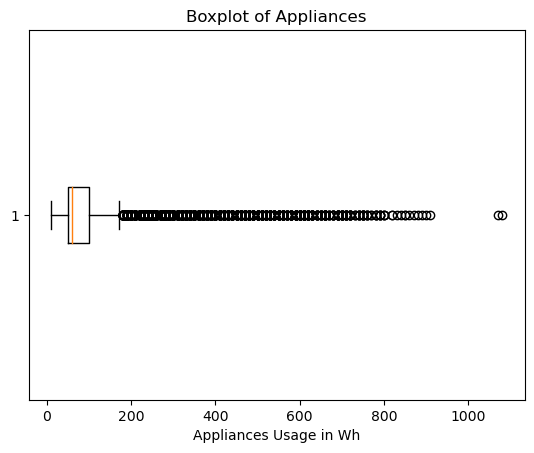

```
count    19735.000000
mean        97.694958
std        102.524891
min         10.000000
25%         50.000000
50%         60.000000
75%        100.000000
max       1080.000000
Name: Appliances, dtype: float64
```

```python
plt.boxplot(target_var,vert=False)
plt.title('Boxplot of Appliances')
plt.xlabel('Appliances Usage in Wh')
plt.show()
display(target_var.describe())
```

```python
def energy_usage_per_time(data, column):
    """
    This function is used to display the Appliances usage per time.
    column: str, the column to be used for the time (daily, weekly, etc).
    """

    df_time = data.groupby(column).median()
    q3_hours = df_time['Appliances'].quantile(0.75)
    q1_hours = df_time['Appliances'].quantile(0.25)
    q2_hours = df_time['Appliances'].median()

    unique_values = data[column].nunique()

    plt.bar(df_time.index,df_time['Appliances'])
    plt.hlines(y=q3_hours,colors='grey',linestyles='--',xmin=0,xmax=unique_values,label=f'Q3 Appliances Usage: {q3_hours}')
    plt.hlines(y=q2_hours,colors='red',linestyles='--',xmin=0,xmax=unique_values,label=f'Q2 Appliances Usage: {q2_hours}')
    plt.hlines(y=q1_hours,colors='grey',linestyles='--',xmin=0,xmax=unique_values,label=f'Q1 Appliances Usage: {q1_hours}')

    plt.title(f'Median Appliances Usage per {column}')
    plt.xticks(np.arange(0,unique_values,1))
    plt.xlabel(column)
    plt.ylabel('Appliances Usage in Wh')
    plt.legend(loc='upper center', bbox_to_anchor=(0.5, -0.05),fancybox=True, shadow=True, ncol=3)
    plt.show()

    return q3_hours, q2_hours, q1_hours
```

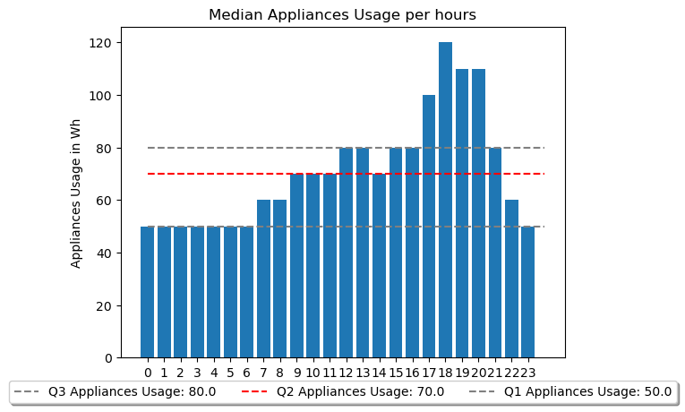

```python
# extract the hours from date data
df_dev['date']=pd.to_datetime(df_dev['date'])
df_dev['hours']=df_dev['date'].dt.hour

q3_hours,q2_hours,q1_hours=energy_usage_per_time(df_dev, 'hours')
```

We could see from the plot above at 17-20 the energy consumption is the highest at all time. On the other hand, at 23, 0-6 the energy consumption is the lowest, since there are only a few people uses energy at that time.

```python
def energy_mark(x,q3,q2,q1):
    """
    This function is used to convert the energy usage into a categorical variable based on the statistics of the energy usage.
    """
    if x > q3:
        return 3
    elif x > q2:
        return 2
    elif x > q1:
        return 1
    else:
        return 0
```

```python
df_dev['hour_energy_mark'] = df_dev['Appliances'].apply(energy_mark,args=(q3_hours,q2_hours,q1_hours))
```

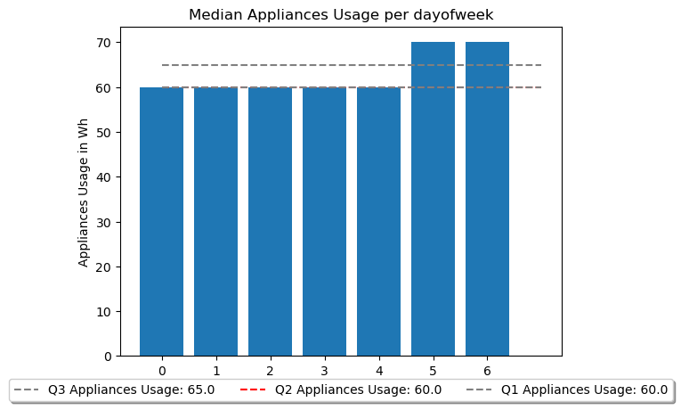

```python
df_dev['dayofweek']=df_dev['date'].dt.dayofweek

q3_dow,q2_dow,q1_dow=energy_usage_per_time(df_dev, 'dayofweek')
```

As we could see, on the weekends the energy consumption is higher than on weekdays.

```python
df_dev['dow_energy_mark'] = df_dev['Appliances'].apply(energy_mark,args=(q3_dow,q2_dow,q1_dow))
```

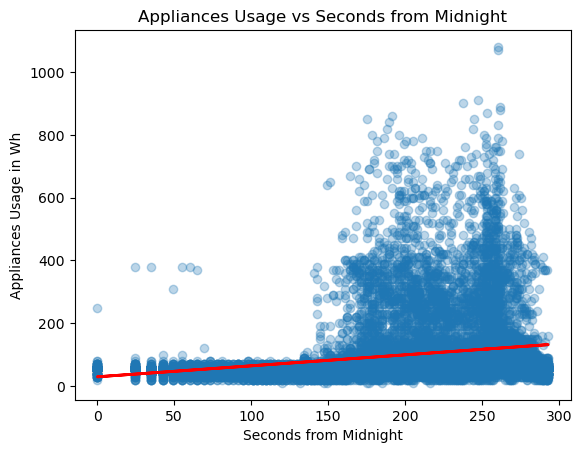

```python
from sklearn.linear_model import LinearRegression

# count the number of seconds from midnight
df_dev['nsm'] = df_dev['date'].dt.hour*3600 + df_dev['date'].dt.minute*60 + df_dev['date'].dt.second

plt.scatter(np.sqrt(df_dev['nsm']), df_dev['Appliances'], alpha=0.3)
plt.ylabel('Appliances Usage in Wh')
plt.xlabel('Seconds from Midnight')

# fit linear regression model
X = np.sqrt(df_dev['nsm']).values.reshape(-1, 1)
y = df_dev['Appliances'].values.reshape(-1, 1)
reg = LinearRegression().fit(X, y)

# plot the linear regression line
plt.plot(X, reg.predict(X), color='red', linewidth=2)
plt.title('Appliances Usage vs Seconds from Midnight')
plt.show()
```

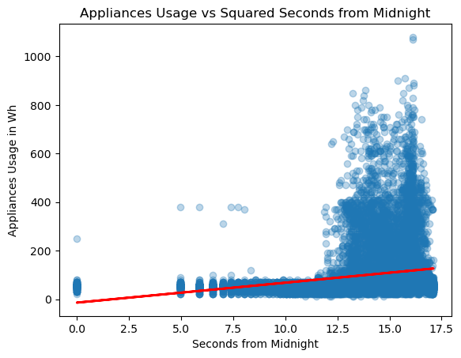

```python
df_dev['sqrt_nsm'] = np.sqrt(df_dev['nsm'])

plt.scatter(np.sqrt(df_dev['sqrt_nsm']), df_dev['Appliances'], alpha=0.3)
plt.ylabel('Appliances Usage in Wh')
plt.xlabel('Seconds from Midnight')

# fit linear regression model
X = np.sqrt(df_dev['sqrt_nsm']).values.reshape(-1, 1)
y = df_dev['Appliances'].values.reshape(-1, 1)
reg = LinearRegression().fit(X, y)

# plot the linear regression line
plt.plot(X, reg.predict(X), color='red', linewidth=2)
plt.title('Appliances Usage vs Squared Seconds from Midnight')

plt.show()
```

```python
# features and target variable Pearson Correlation
pd.DataFrame(df_dev.corr().iloc[:,0].sort_values(ascending=False))
```

|  | Appliances |
| --- | --- |
| Appliances | 1.000000 |
| hour_energy_mark | 0.608580 |
| dow_energy_mark | 0.520935 |
| sqrt_nsm | 0.239137 |
| nsm | 0.217152 |
| hours | 0.216792 |
| lights | 0.197278 |
| T2 | 0.120073 |
| T6 | 0.117638 |
| T_out | 0.099155 |
| Windspeed | 0.087122 |
| RH_1 | 0.086031 |
| T3 | 0.085060 |
| T1 | 0.055447 |
| dayofweek | 0.043649 |
| T4 | 0.040281 |
| T8 | 0.039572 |
| RH_3 | 0.036292 |
| T7 | 0.025801 |
| T5 | 0.019760 |
| RH_4 | 0.016965 |
| Tdewpoint | 0.015357 |
| T9 | 0.010010 |
| RH_5 | 0.006955 |
| Visibility | 0.000230 |
| rv1 | -0.011145 |
| rv2 | -0.011145 |
| Press_mm_hg | -0.034885 |
| RH_9 | -0.051462 |
| RH_7 | -0.055642 |
| RH_2 | -0.060465 |
| RH_6 | -0.083178 |
| RH_8 | -0.094039 |
| RH_out | -0.152282 |

From the table above, the new features: hour_energy_mark, dow_energy_mark and sqrt_nsm, are the top tree highest correlated features with Appliance variable. On the other hand, Visibility, RH_5, which are the features that have the lowest correlation with Appliance will not be dropped, since there could be a non-linear relation between these features and the target variable.

#### Analyse Predictor Variable

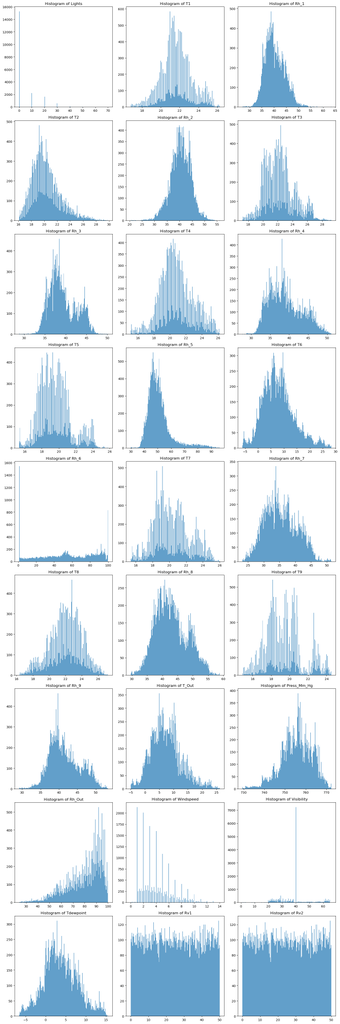

```python
#Chat-GPT 3.5 prompt: Make me a histogram of the features
# get the feature columns
feature_columns = df_dev.drop(['date','Appliances','hours', 'hour_energy_mark','dayofweek', 'dow_energy_mark', 'nsm', 'sqrt_nsm'],axis=1).columns

# calculate the number of rows and columns for the subplots
num_rows = int(np.ceil(len(feature_columns) / 3))
num_cols = min(len(feature_columns), 3)

# create the subplots
fig, axes = plt.subplots(num_rows, num_cols, figsize=(15, 5*num_rows))

# flatten the axes array
axes = axes.flatten()

# iterate over the feature columns and create a histogram subplot for each column
for i, column in enumerate(feature_columns):
    axes[i].hist(df_dev[column], bins=200, alpha=0.7)
    axes[i].set_title(f'Histogram of {column.title()}')

# remove any empty subplots
if len(feature_columns) < len(axes):
    for j in range(len(feature_columns), len(axes)):
        fig.delaxes(axes[j])

# adjust the spacing between subplots
fig.tight_layout()

# Show the plot
plt.show()
# end of Chat-GPT 3.5 prompt------------------------------------------------------------
```

```python
# Chat-GPT prompt: Find high correlated columns

# Calculate the correlation matrix
corr_matrix = df_dev.drop(['date','hours', 'hour_energy_mark','dayofweek', 'dow_energy_mark', 'nsm', 'sqrt_nsm'],axis=1).corr().abs()

# Create a boolean mask to identify highly correlated features
high_corr_mask = corr_matrix.mask(np.tril(np.ones_like(corr_matrix, dtype=bool))).stack().abs() > 0.8

# Get the indices of highly correlated features
high_corr_pairs = high_corr_mask[high_corr_mask].index.tolist()
```

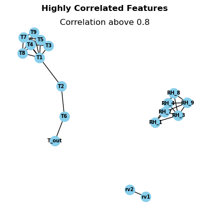

```python
import networkx as nx

fig = plt.figure(figsize=(4,4))

# create an empty graph
G = nx.Graph()

# add edges from the list of tuples
G.add_edges_from(high_corr_pairs)

pos = nx.spring_layout(G, k=0.5)

# draw the graph
nx.draw(G, pos,with_labels=True, node_color='skyblue', node_size=200, font_size=7, font_weight='bold')

# display the graph
plt.title('Highly Correlated Features', weight='bold')
plt.suptitle('Correlation above 0.8')
plt.show()
```

From the above graph, we could see the correlation between features. The connected nodes mean that it has correlation that is greater than 0.8. In (Monghadam 2021), the highly correlated column will not be dropped, instead the dimension will be reduce using PCA.

```python
from sklearn.decomposition import PCA

# T variable
pca = PCA(n_components=5, random_state=42)
X_t = df_dev[['T1', 'T2', 'T3', 'T4', 'T5', 'T6', 'T7', 'T8', 'T9','T_out']].copy()
X_t_reduce = pca.fit_transform(X_t)
print(f"Total Variance: {np.sum(pca.explained_variance_ratio_)}\n")
print(f'Varice per Component:\n{pca.explained_variance_ratio_}')
```

[output not shown]

```python
pca = PCA(n_components=5, random_state=42)
X_rh = df_dev[['RH_1','RH_3','RH_4','RH_7','RH_8','RH_9']].copy()
X_rh_reduce = pca.fit_transform(X_rh)
print(f"Total Variance: {np.sum(pca.explained_variance_ratio_)}\n")
print(f'Varice per Component:\n{pca.explained_variance_ratio_}')
```

```
Total Variance: 0.9893188977325805

Varice per Component:
[0.87259822 0.05177221 0.02599827 0.02417671 0.01477348]
```

For these features, only the first PCA component will be used, since it has already explained 87.3% of the total variance.

```python
pca = PCA(n_components=1, random_state=42)
X_rv = df_dev[['rv1','rv2']].copy()
X_rv_reduce = pca.fit_transform(X_rv)
print(f"Total Variance: {np.sum(pca.explained_variance_ratio_)}\n")
print(f'Varice per Component:\n{pca.explained_variance_ratio_}')
```

```
Total Variance: 0.9999999999999987

Varice per Component:
[1.]
```

### 3. Pre-process the data

```python
from sklearn.pipeline import Pipeline
from sklearn.preprocessing import RobustScaler, StandardScaler
from sklearn.base import BaseEstimator, TransformerMixin
from sklearn.model_selection import GridSearchCV
from sklearn.model_selection import cross_val_score


class EDAResult(BaseEstimator,TransformerMixin):
    def __init__(self,columns_to_drop=None):
        self.columns_to_drop = columns_to_drop
        self.fitted = False

    @staticmethod
    def get_statistics(data,column):
        df_time = data.groupby(column)['Appliances'].median()
        q3_hours = df_time.quantile(0.75)
        q1_hours = df_time.quantile(0.25)
        q2_hours = df_time.median()

        return q3_hours, q2_hours, q1_hours

    def fit(self,X,y=None):
        if self.fitted == False:

            # get Q1, Q2, and Q3 appliances usage per hour
            self.q3_hours,self.q2_hours,self.q1_hours=self.get_statistics(X, 'hours')
            self.fitted = True

        return self

    def transform(self,X):

        # get the hour energy mark column
        X['hour_energy_mark'] = X['Appliances'].apply(energy_mark,args=(self.q3_hours,self.q2_hours,self.q1_hours))

        # get weekend column
        X['weekend'] = X['dayofweek'].apply(lambda x: 1 if x >= 5 else 0)

        # count the number of seconds from midnight
        X['nsm'] = X['date'].dt.hour*3600 + X['date'].dt.minute*60 + X['date'].dt.second
        X['sqrt_nsm'] = np.sqrt(X['nsm'])

        # drop the highly correlated variables from the dataframe
        try:
            X.drop(columns=self.columns_to_drop,axis=1,inplace=True)
        except:
            pass

        # drop the Target Variable (Applicances) and other columns
        X.drop(['date','Appliances','nsm','dayofweek','hours'],axis=1,inplace=True)

        return X

class PCATransformer(BaseEstimator,TransformerMixin):
    def __init__(self):
        self.pca_t = PCA(n_components=1, random_state=42)
        self.pca_rh = PCA(n_components=1, random_state=42)
        self.pca_rv = PCA(n_components=1, random_state=42)
        self.fitted = False
        self.t_col = ['T1', 'T2', 'T3', 'T4', 'T5', 'T6', 'T7', 'T8', 'T9','T_out']
        self.rh_col = ['RH_1','RH_3','RH_4','RH_7','RH_8','RH_9']
        self.rv_col = ['rv1','rv2']

    def fit(self,X,y=None):
        if self.fitted == False:
            self.pca_t.fit(X[self.t_col])
            self.pca_rh.fit(X[self.rh_col])
            self.pca_rv.fit(X[self.rv_col])
            self.fitted = True
        return self

    def transform(self,X):
        X_t = self.pca_t.transform(X[self.t_col])
        X_rh = self.pca_rh.transform(X[self.rh_col])
        X_rv = self.pca_rv.transform(X[self.rv_col])

        X.drop(columns=self.t_col+self.rh_col+self.rv_col,axis=1,inplace=True)
        X_combine = np.hstack([X,X_t,X_rh,X_rv])
        return X_combine
```

### 4. Implement, train and test prediction models

Root Mean Squared Error (RMSE) is used as the evaluation metrics for this experiment. The advantage of using RMSE is that it provides a measure of the average deviation of predicted values from the actual values in the same units as the target variable. This makes it easy to interpret and compare across different models or datasets. Additionally, RMSE penalizes large errors more heavily than smaller ones, making it particularly useful for tasks where accurately predicting extreme values is crucial.

```python
from sklearn.model_selection import train_test_split

df['date']=pd.to_datetime(df['date'])
df['hours']=df['date'].dt.hour
df['dayofweek']=df['date'].dt.dayofweek

X = df.copy() # the target variable, Appliances, will be dropped in the EDAResult pipeline
y = df['Appliances']

# split the data into training and testing sets
X_train, X_test, y_train, y_test = train_test_split(X,y,test_size=0.2,random_state=42)
```

```python
print(f"Training Data Dimension: {X_train.shape}")
print(f"Testing Data Dimension: {X_test.shape}")
```

```
Training Data Dimension: (15788, 31)
Testing Data Dimension: (3947, 31)
```

#### Grid Search

In this section, the model will be iterate using Grid Search to find the best Hyperparameter to fit the data

Robust Scaler will be used, since there are som features that is skewed, so it is better to use median rather than mean.

#### Linear Regression

```python
from sklearn.linear_model import LinearRegression

X_train_lr = X_train.copy()

pipeline = Pipeline([
    ('eda',EDAResult()),
    ('pca',PCATransformer()),
    ('scaler',RobustScaler()),
    ('model',LinearRegression())
])

cv_score = cross_val_score(pipeline,X_train_lr,y_train,scoring='neg_mean_squared_error',cv=10,n_jobs=-1)

print(f"Best Score: {np.mean(np.sqrt(cv_score*-1))}")
```

```
Best Score: 81.03845620178146
```

#### XGBoost

```python
from xgboost import XGBRegressor

X_train_xgb = X_train.copy()

param_model = {'model__max_depth' : [5,10,50],
               'model__lambda' : [1,10,20],
               'model__min_child_weight':[1,5,10]}

pipeline = Pipeline([
    ('eda',EDAResult()),
    ('pca',PCATransformer()),
    ('scaler',RobustScaler()),
    ('model',XGBRegressor())
])

grid_search_rf = GridSearchCV(pipeline, param_grid={**param_model}, cv=10, scoring='neg_mean_squared_error', verbose=1, n_jobs=-1)
grid_search_rf.fit(X_train_xgb, y_train)

print("Best Parameters:", grid_search_rf.best_params_)
print(f"Best Score: {np.mean(np.sqrt(grid_search_rf.best_score_*-1))}")
```

```
Fitting 10 folds for each of 27 candidates, totalling 270 fits
Best Parameters: {'model__lambda': 20, 'model__max_depth': 50, 'model__min_child_weight': 5}
Best Score: 63.77213924769492
```

#### Random Forest

```python
from sklearn.ensemble import RandomForestRegressor

X_train_rf = X_train.copy()

param_model = {'model__max_depth' : [5,10,50],
               'model__n_estimators' : [100,200,300],
               'model__criterion':["squared_error",'friedman_mse']}

pipeline = Pipeline([
    ('eda',EDAResult()),
    ('pca',PCATransformer()),
    ('scaler',RobustScaler()),
    ('model',RandomForestRegressor(random_state=1))
])

grid_search_rf = GridSearchCV(pipeline, param_grid={**param_model}, cv=10, scoring='neg_mean_squared_error', verbose=1, n_jobs=-1)
grid_search_rf.fit(X_train_rf, y_train)

print("Best Parameters:", grid_search_rf.best_params_)
print(f"Best Score: {np.mean(np.sqrt(grid_search_rf.best_score_*-1))}")
```

```
Fitting 10 folds for each of 18 candidates, totalling 180 fits
Best Parameters: {'model__criterion': 'squared_error', 'model__max_depth': 50, 'model__n_estimators': 300}
Best Score: 61.99751477842562
```

Each model has each own X_train data because in the pipeline, the X data will be transform and saved as the new transformed data

### 5. Compare the results from all candidate models, choose the best model, justify your choice and discuss the results

From above experiment, Random Forest model yield the lowest RMSE Score. Thus, it is chosen as the best model to predict the test data

```python
X_train_final = X_train.copy()
pipeline = Pipeline([
    ('eda',EDAResult()),
    ('pca',PCATransformer()),
    ('scaler',RobustScaler()),
    ('model',RandomForestRegressor(random_state=1,criterion= 'squared_error', max_depth= 50, n_estimators= 300))
])

pipeline.fit(X_train_final,y_train)
y_pred = pipeline.predict(X_test)
```

```python
from sklearn.metrics import mean_squared_error, mean_absolute_error
print(f"Data Test RMSE: {np.sqrt(mean_squared_error(y_test,y_pred))}")
print(f"Data Test MAPE: {np.sqrt(mean_absolute_error(y_test,y_pred))}")
```

```
Data Test RMSE: 56.762098043387034
Data Test MAPE: 4.879627821017639
```

### 6. Reflect on what you have learned by completing this assignment and how to improve the models

In this assignment I learn how to incorporate PCA with machine learning model. In the beginning of my experiment, the high correlated columns was just deleted. However, using the PCA to reduce the dimentionality result in a better model evaluation, RMSE Score.

To imporve the model in the future, I'm planning to use Neural Network model, since it could capture more complex data characteristic and implement feature selection in the pipeline

### 7. References

- Moghadam, HS 2021, 'Fully component selection: An efficient combination of feature selection and principal component analysis to increase model performance', *Elsevier*, vol. 186, DOI:10.1016/j.eswa.2021.115678.
- Brownlee, J, *How to Scale Data With Outliers for Machine Learning*, Machine Learning Mastery, viewed 25 February 2024, <[https://machinelearningmastery.com/robust-scaler-transforms-for-machine-learning/>](https://machinelearningmastery.com/robust-scaler-transforms-for-machine-learning/%3E)
- Candanendo, LM, Feldheim, V, Deramaix, D 2017, 'Energy and Buildings', *Elsevier*, pp. 81-97, DOI:10.1016/j.enbuild.2017.01.083